# College Score Admission and Ethnicity

antelope

2022-07-31

## Introduction

The SAT test is an effort to increase academic opportunity, however there exist a racial gap in SAT scores and many universities are starting to not require it. In this report, we would like to explore the whether there is a correlation between proportion of ethnicity and average SAT admission score of universities in the United States. Additionally, we would like to know whether there is a difference in the average admission SAT scores of liberal states vs conservative states to better understand significance of SAT and admission between them.

Thesis Statement: There is a racial difference in SAT scores between each ethnicity as shown by the correlation between average SAT admission scores and different ethnicity enrollment proportion of university. Additionally, Liberal state universities have a higher admission SAT score than conservative state universities, which may suggest a more emphasis on SAT scores by liberal universities.

## Background

The dataset we have selected for this analysis is “U.S Department of Education: College Scoreboard” which includes information on institutional characteristics, enrollment, student aid, costs, and student outcomes during the year 1996-97 through 2020-21.

https://collegescorecard.ed.gov/data/

https://worldpopulationreview.com/state-rankings/most-liberal-states

We will be using the following columns for analysis:

- INSTNM - Institution name
- STABBR - State postcode
- SAT_AVG - Average SAT equivalent score of students admitted
- SATVRMID - Midpoint of SAT scores at the institution (critical reading)
- SATMTMID - Midpoint of SAT scores at the institution (math)
- UGDS - Enrollment of undergraduate certificate/degree-seeking students
- UGDS_WHITE - Total share of enrollment of undergraduate degree-seeking students who are white
- UGDS_BLACK - Total share of enrollment of undergraduate degree-seeking students who are black
- UGDS_HISP - Total share of enrollment of undergraduate degree-seeking students who are Hispanic
- UGDS_ASIAN - Total share of enrollment of undergraduate degree-seeking students who are Asian
- UGDS_AIAN - Total share of enrollment of undergraduate degree-seeking students who are American Indian/Alaska Native
- UGDS_NHPI - Total share of enrollment of undergraduate degree-seeking students who are Native Hawaiian/Pacific Islander
- UGDS_2MOR - Total share of enrollment of undergraduate degree-seeking students who are two or more races
- UGDS_NRA - Total share of enrollment of undergraduate degree-seeking students who are non-resident aliens

Unusual factors:

- All of the score and ethnicity proportion columns are type char which will need to be converted to numeric for analysis

Here we focus on the SATs, ACTs, and ethnicity of a student

Some university do not have the SATs, ACTs score, and information about ethnicity of students, so we are going to drop those schools out

## Analysis

This is the map showing the proportion of each ethnicity and SAT/ACT scores according to each institution

[interactive chart not shown]

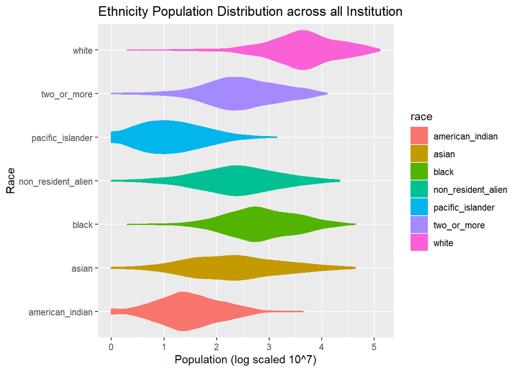

Population Distribution for each races

- ethnicity with highest population is white

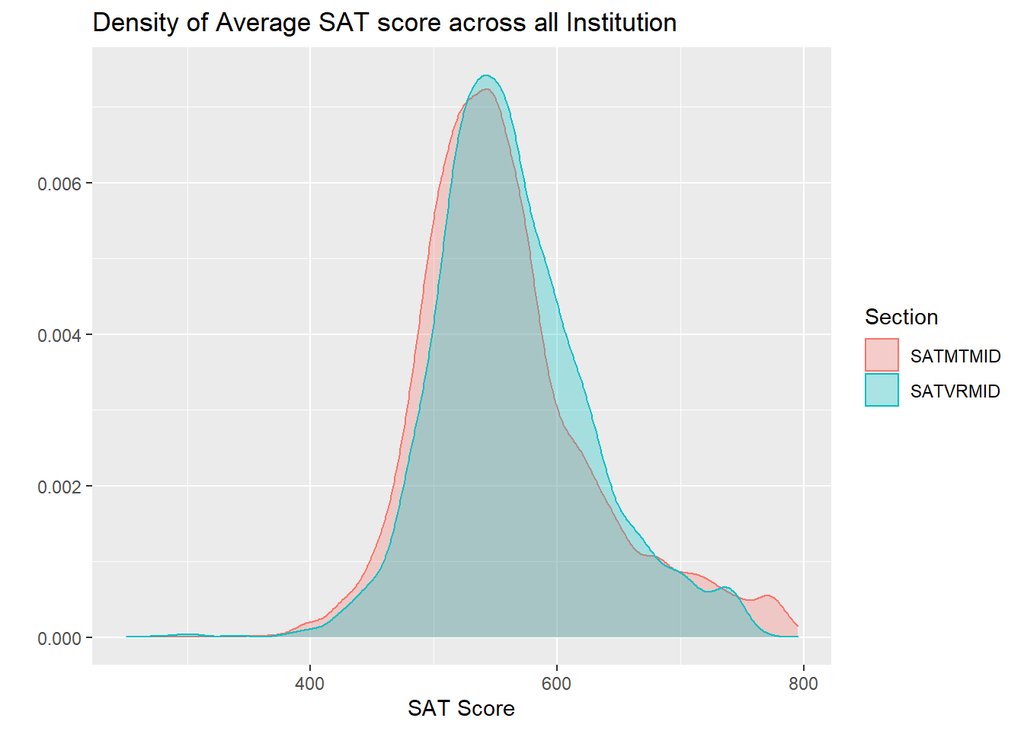

Average SAT score :

- The distribution of SAT math and SAT verbal is quite similar
- Achieving perfect SAT verbal is more rare

[figure not shown]

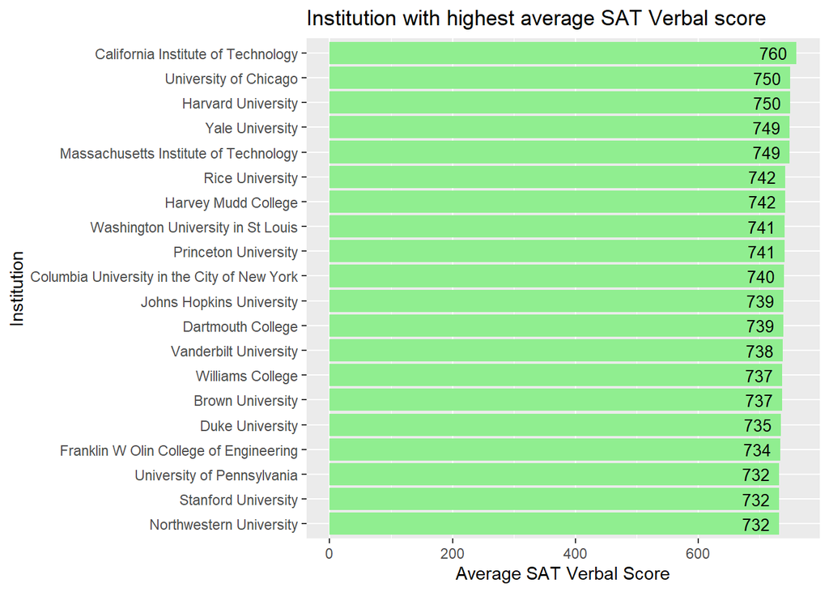

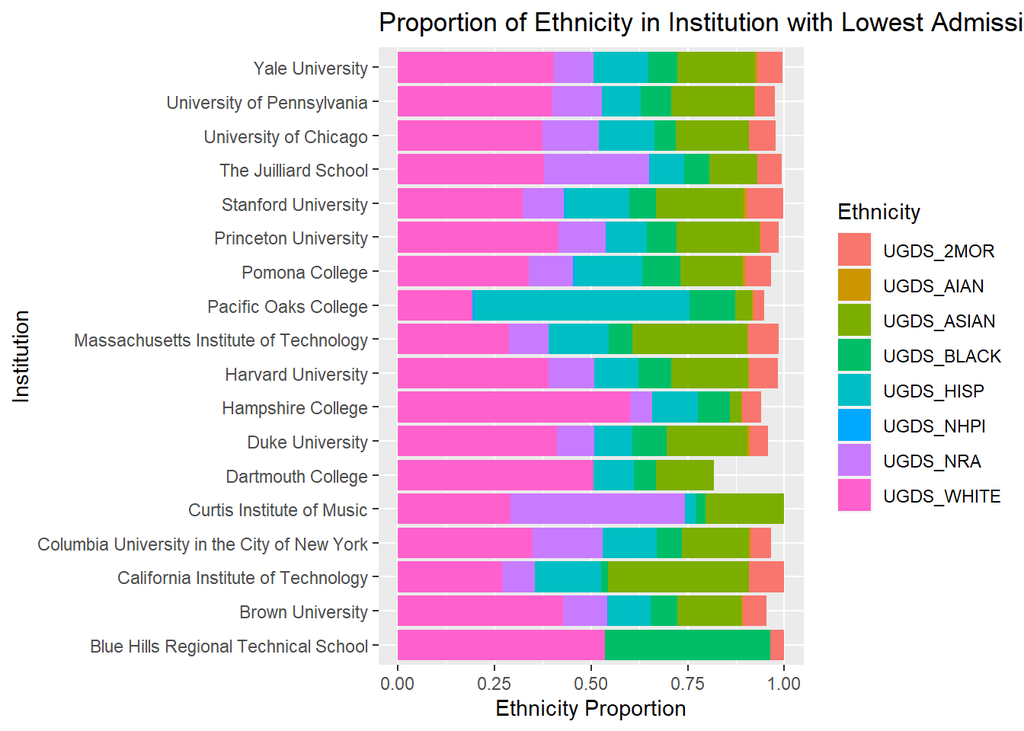

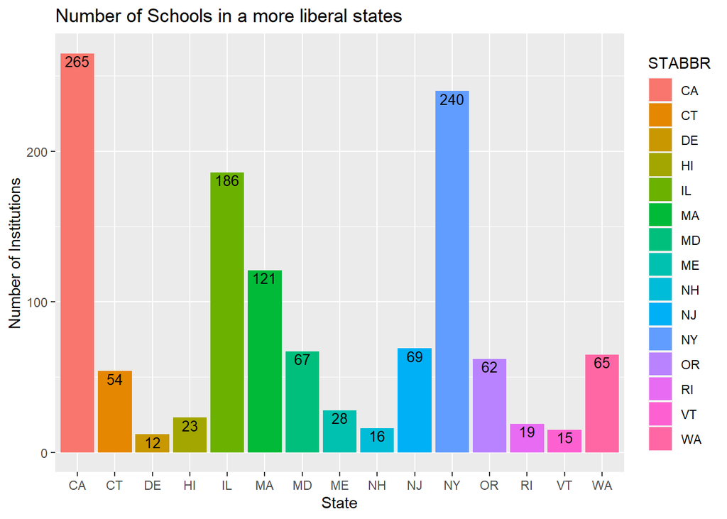

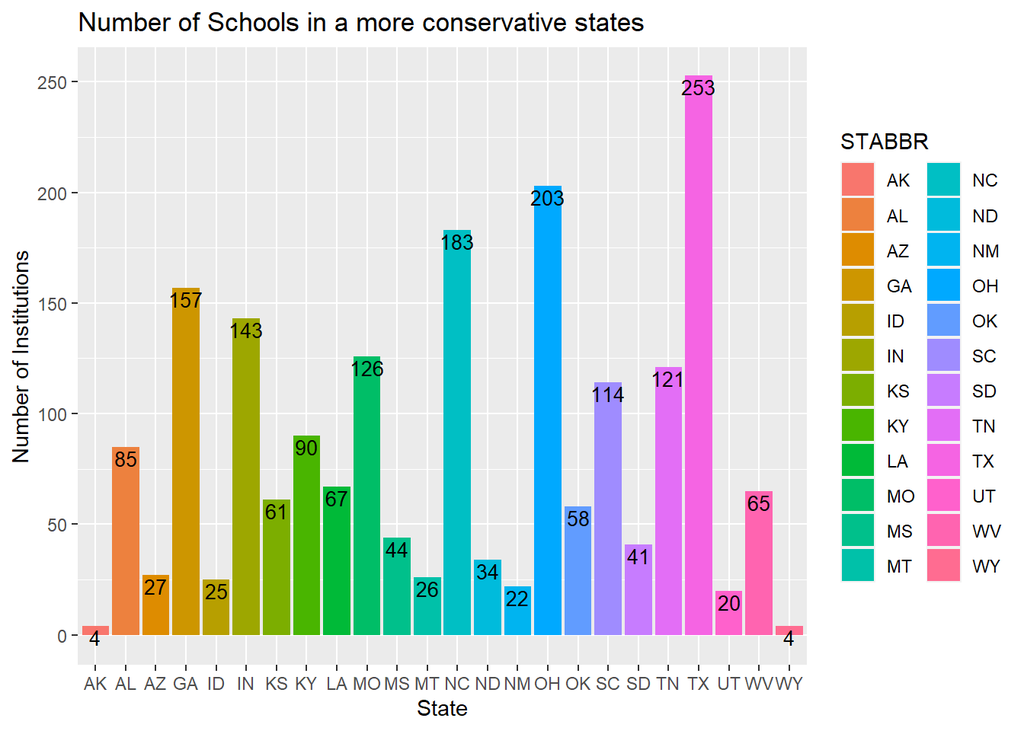

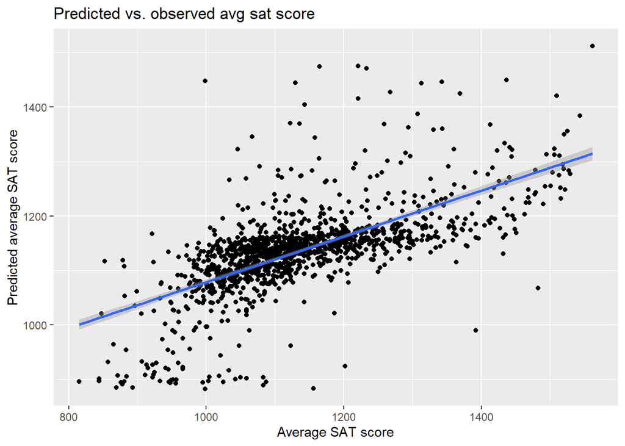

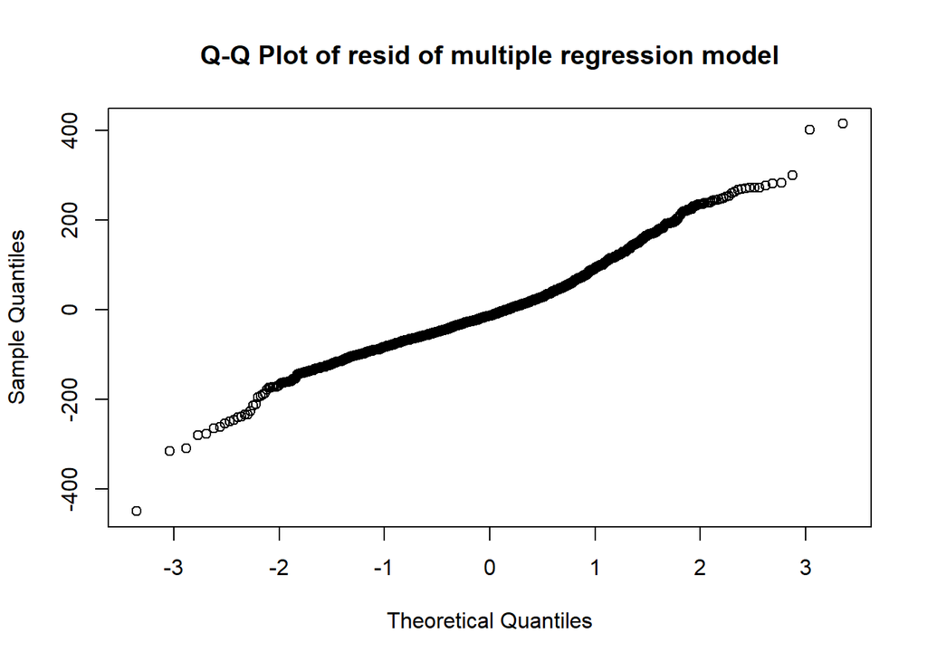

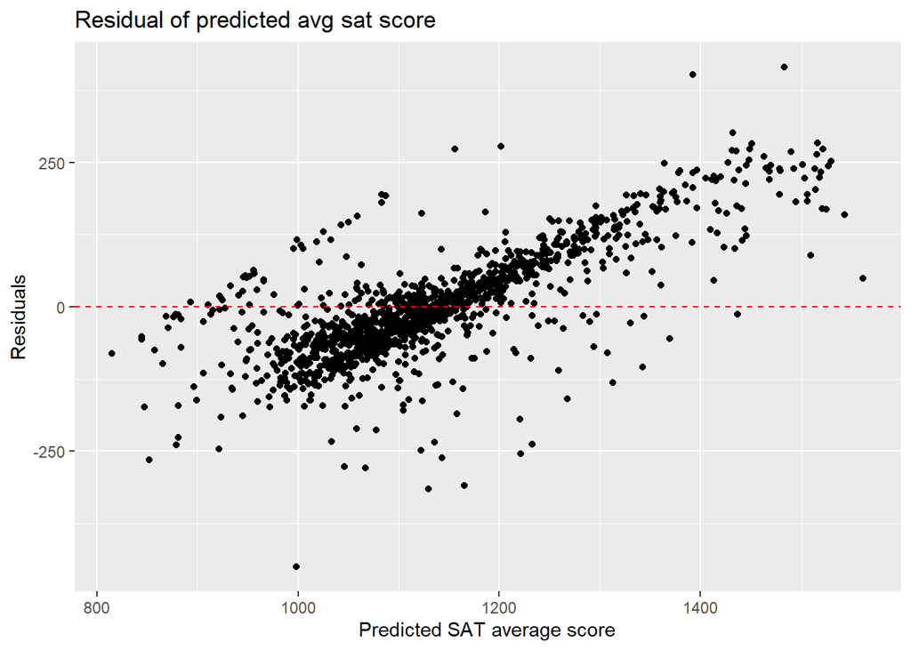

```
##
## Call:
## lm(formula = SAT_AVG ~ UGDS_WHITE + UGDS_BLACK + UGDS_ASIAN,
##     data = score)
##
## Residuals:
##     Min      1Q  Median      3Q     Max
## -449.67  -60.71  -13.09   48.44  415.53
##
## Coefficients:
##             Estimate Std. Error t value Pr(>|t|)
## (Intercept)   990.03      16.43  60.261  < 2e-16 ***
## UGDS_WHITE    182.04      20.45   8.902  < 2e-16 ***
## UGDS_BLACK   -110.74      24.01  -4.612  4.4e-06 ***
## UGDS_ASIAN   1190.96      57.71  20.635  < 2e-16 ***
## ---
## Signif. codes:  0 '***' 0.001 '**' 0.01 '*' 0.05 '.' 0.1 ' ' 1
##
## Residual standard error: 96.6 on 1251 degrees of freedom
## Multiple R-squared:  0.4206, Adjusted R-squared:  0.4192
## F-statistic: 302.6 on 3 and 1251 DF,  p-value: < 2.2e-16
```

## Discussion

We would like to know whether there is a correlation between proportion of ethnicity and average sat score

Assumption:

Assume that the random error is approximately normally distributed as confirmed by the normal q-q residual plot which is quite linear and that mean is 0 and constant variance.

The linear model fitted is given by y_hat = 990.03 + 182.04*white - 110.74*black + 1190.96*asian

Hypothesis testing:

$H_o =$ There is no effect on average SAT score due to proportion of ethnicity (beta_white = beta_black = beta_asian = 0)

$H_a =$ There is some effect on average SAT score due to proportion of ethnicity, at least one of the proportion have effect on avg SAT score (beta_white != 0 || beta_black != 0 || beta_asian != 0).

Since F = 302.6 where p < 2.2e-16, at the significance of alpha = 0.05 we can reject the null hypothesis that there is no effect on average SAT score due to proportion of ethnicity.

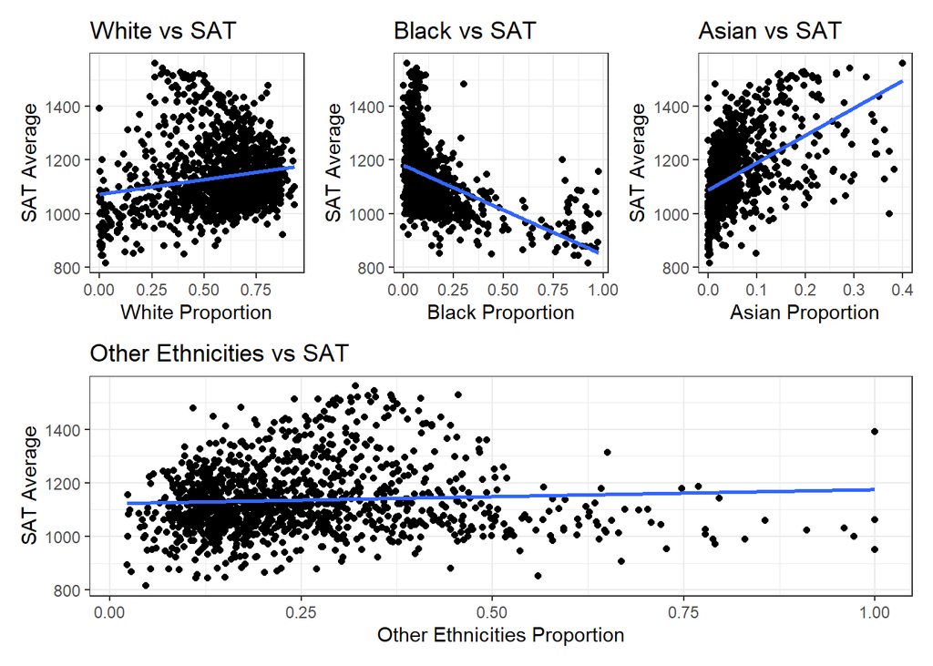

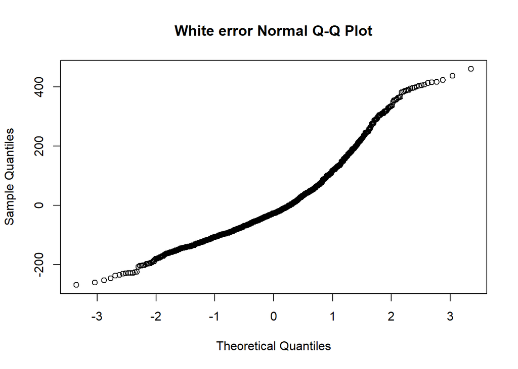

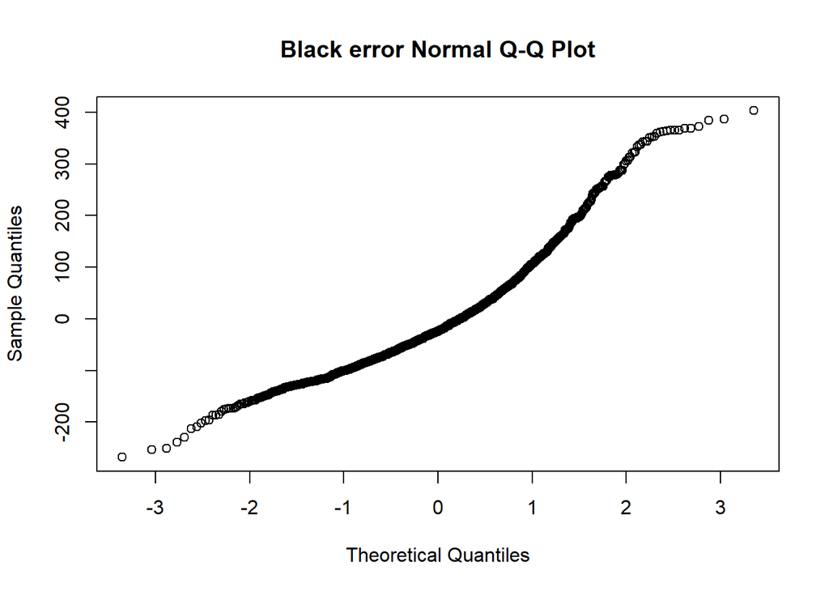

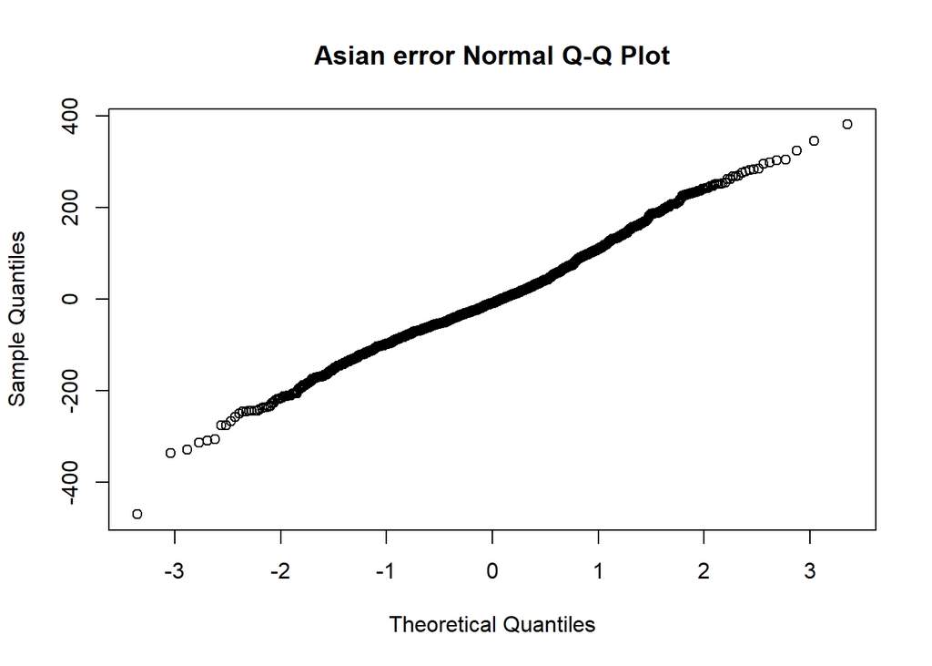

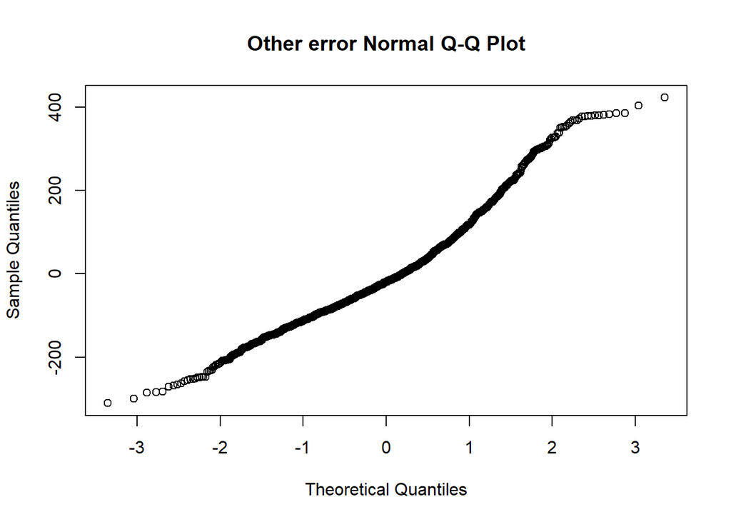

```
##
## Call:
## lm(formula = SAT_AVG ~ UGDS_WHITE, data = score)
##
## Residuals:
##     Min      1Q  Median      3Q     Max
## -269.09  -84.37  -26.93   54.15  460.51
##
## Coefficients:
##             Estimate Std. Error t value Pr(>|t|)
## (Intercept)  1072.52      10.06 106.642  < 2e-16 ***
## UGDS_WHITE    109.12      16.36   6.672 3.78e-11 ***
## ---
## Signif. codes:  0 '***' 0.001 '**' 0.01 '*' 0.05 '.' 0.1 ' ' 1
##
## Residual standard error: 124.6 on 1253 degrees of freedom
## Multiple R-squared:  0.03431,    Adjusted R-squared:  0.03354
## F-statistic: 44.51 on 1 and 1253 DF,  p-value: 3.782e-11
```

```
## white p-val: 3.82974e-11
```

```
##
## Call:
## lm(formula = SAT_AVG ~ UGDS_BLACK, data = score)
##
## Residuals:
##     Min      1Q  Median      3Q     Max
## -268.06  -77.75  -24.29   53.40  403.10
##
## Coefficients:
##             Estimate Std. Error t value Pr(>|t|)
## (Intercept) 1180.089      4.013  294.07   <2e-16 ***
## UGDS_BLACK  -333.950     18.278  -18.27   <2e-16 ***
## ---
## Signif. codes:  0 '***' 0.001 '**' 0.01 '*' 0.05 '.' 0.1 ' ' 1
##
## Residual standard error: 112.7 on 1253 degrees of freedom
## Multiple R-squared:  0.2104, Adjusted R-squared:  0.2097
## F-statistic: 333.8 on 1 and 1253 DF,  p-value: < 2.2e-16
```

```
## black p-val: 2.671523e-66
```

```
##
## Call:
## lm(formula = SAT_AVG ~ UGDS_ASIAN, data = score)
##
## Residuals:
##     Min      1Q  Median      3Q     Max
## -470.41  -68.01   -9.57   65.58  380.49
##
## Coefficients:
##             Estimate Std. Error t value Pr(>|t|)
## (Intercept) 1087.881      3.863  281.63   <2e-16 ***
## UGDS_ASIAN  1022.990     49.771   20.55   <2e-16 ***
## ---
## Signif. codes:  0 '***' 0.001 '**' 0.01 '*' 0.05 '.' 0.1 ' ' 1
##
## Residual standard error: 109.7 on 1253 degrees of freedom
## Multiple R-squared:  0.2521, Adjusted R-squared:  0.2516
## F-statistic: 422.5 on 1 and 1253 DF,  p-value: < 2.2e-16
```

```
## asian p-val: 3.950774e-81
```

```
## white vs SAT correlation coefficient: 0.1852211
```

```
## black vs SAT correlation coefficient: -0.4586655
```

```
## asian vs SAT correlation coefficient: 0.5021452
```

```
## other ethnicity vs SAT correlation coefficient: 0.06034408
```

Having found out that there is at least a ethicity proportion variable that has an effect on the mean average SAT admission score, we would like to test each ethicity to find whether it has an effect on average SAT score.

Assumption:

We are using t-statistic = (theta_hat - hypothesized) / SE, with degree of freedom = 1253

Hypothesis: (for each, simplified here)

$H_o =$ theta = 0

$H_a =$ theta != 0

Setting significance alpha = 0.05 we get that p-value for each ethnicity is:

white = 3.82974e-11 black = 2.671523e-66 asian = 3.950774e-81

The evidence suggest that we can reject the null hypothesis meaning that each ethnicity proportion has an effect on the average SAT score.

The graph above show that white, asian and other ethnicity have positive correlation while black ethnicity has negative correlation.

**Shortcomings:**

Our residual plot is not quite linear, however it does give a general sense of the correlation, does somewhat explain our observation, and we are just using for explaining not prediction. We got a decent r-squared of 0.4192 which means that about 41% of the variability observed could be explained by our model.

Also, since we don’t have the admission score for each student but instead an average of all students, there could be bias if we use proportion of ethnicity vs SAT score. For example, one institution can have higher white proportion but the minority students who are not white might score very high so that the average admission score is high.

*Next, we will perform a hypothesis testing on the average score of sat between red states and blue states*

**Hypothesis testing:**

**Population and Sample:**

Population -> Average SAT score of each institution in the US

Sample -> Average SAT score of each institution during 2017-2021 where admission score is not missing (3215 samples)

**Statistical Model:**

Institutions are $x_1,…,x_n$ for $n=3215$

Model these institutions as a random sample from the larger population

Let $F$ be this unspecified distribution

Let $μ$ be the mean

Let $σ$ be the standard deviation

$Xi∼F(μ,σ),i=1,…,n$

$Yi∼F2(μ2,σ2),i=1,…,n2$

**State Hypothesis:**

$H_o =$ There is no difference between average sat score of a more liberal states and a more conservative states

$H_a =$ There is a difference between average sat score of a more liberal states and a more conservative states

**Choose a Test Statistic:**

Test statistic $t=(\overline{x}−\overline{y})/(SE(\overline{x}−\overline{y}))$

```
##
##  Welch Two Sample t-test
##
## data:  blue_score and red_score
## t = 6.8182, df = 621.72, p-value = 2.186e-11
## alternative hypothesis: true difference in means is not equal to 0
## 95 percent confidence interval:
##  43.98159 79.56565
## sample estimates:
## mean of x mean of y
##  1171.351  1109.577
```

**Interpretation**

We are 95% confident that the average sat score of a more liberal state is between 43.98159 and 79.56565 higher than the average sat score of a more conservative state.

**Potential future directions for additional work**

- If we could find the admission score of each student and the institution they attend, we could better understand how each ethnicity performs
- After collecting individual student’s data, we could see if blue states have higher diversity in ethnicity than red states

**Conclusion** There is correlation between the proportion of white, black, and asian enrollment ethnicity and the average SAT admission score evident by p-value white = 3.82974e-11, black = 2.671523e-66, and asian = 3.950774e-81. Which suggest that there is a gap in SAT with relation to ethnicity. Liberal state also has higher average SAT scores than conservative state given by 95% confidence interval [43.98159, 79.56565] which may suggest that liberal states emphasize more on SAT scores.